# Review Day 1: Choosing the right chart

The easiest place to start when talking about what chart type you are going to use is *what is your x-axis?* It’s not perfect, but it’s a solid place to start.

```r
library(tidyverse)
logs <- read_csv("~/Dropbox/SPMC350-Data-Literacy-and-Analytics-in-Sports/logs.csv")
```

#### My x-axis is a category, like a team or a player.

So with our log data, we have a column Team. Let’s say we’re interested in Big 10 rebounding. So we have a dataset that looks like this:

```r
big10 <- logs %>% filter(Conference == "Big Ten") %>% group_by(Team) %>% summarize(rebounds = sum(TeamTotalRebounds))

head(big10)
```

| Team | rebounds |
| --- | --- |
| Illinois Fighting Illini | 800 |
| Indiana Hoosiers | 897 |
| Iowa Hawkeyes | 898 |
| Maryland Terrapins | 1022 |
| Michigan State Spartans | 1087 |
| Michigan Wolverines | 904 |

So we have two fields. One is a category, one is magnitude – how much bigger is A than B than C and so forth. And we have 14 records. With this, our first choice is a bar chart.

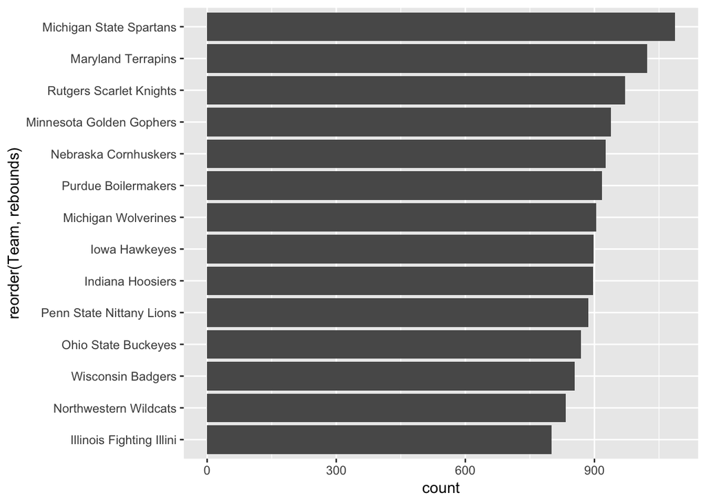

```r
ggplot(big10) + geom_bar(aes(x=reorder(Team, rebounds), weight=rebounds)) + coord_flip()
```

#### My x-axis is a date, part 1

If we have date based information – even if it’s not really a date, it’s a year or some other date like thing – then we’re talking about change over time. If we have a date as our x-axis, then we’re talking about a line chart.

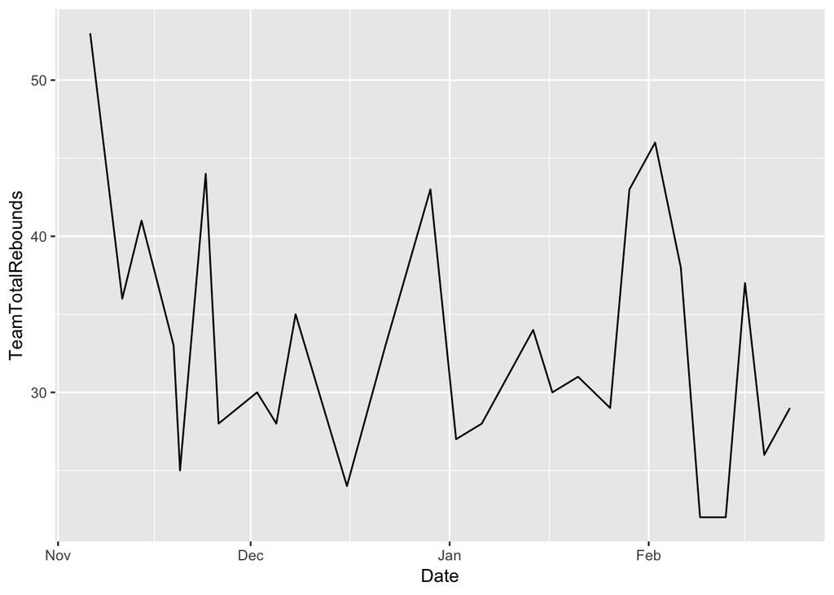

```r
nulines <- logs %>% filter(Conference == "Big Ten" & Team == "Nebraska Cornhuskers")

ggplot(nulines) + geom_line(aes(x=Date, y=TeamTotalRebounds, group=Team))
```

#### My x-axis is a date, part 2

If my x-axis is a date, but I’m looking at PROGRESS over the season, then the chart I want is a step chart.

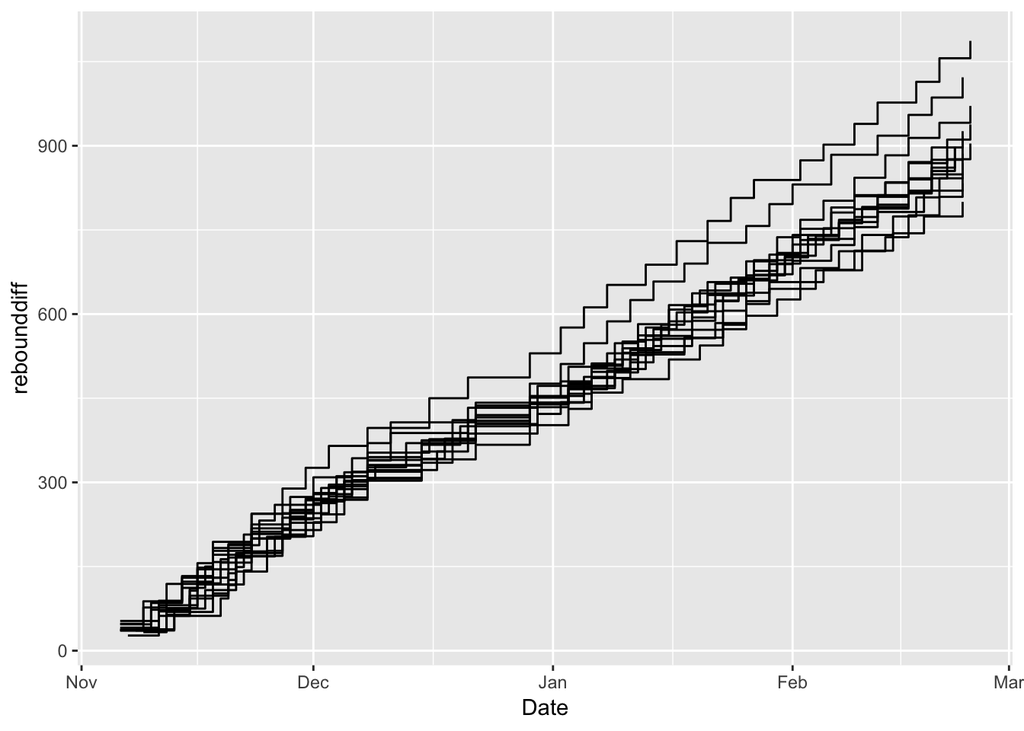

```r
big10step <- logs %>% filter(Conference == "Big Ten") %>% group_by(Team) %>% mutate(rebounddiff = cumsum(TeamTotalRebounds))

ggplot(big10step) + geom_step(aes(x=Date, y=rebounddiff, group=Team))
```

#### My x-axis is a number, and so is my y-axis.

If we have numbers a go-go, then we’re in scatterplot territory. What do scatterplots do? Two things – show relationship between two numbers and helps you look for outliers.

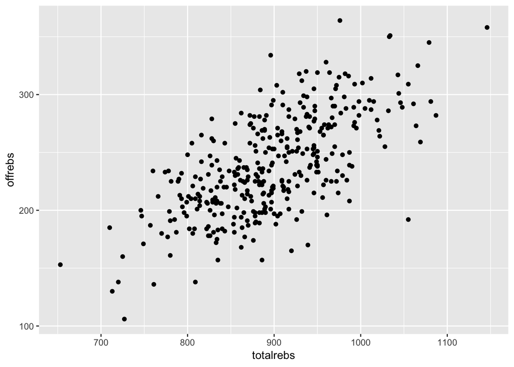

```r
rebscatter <- logs %>% group_by(Team) %>% summarize(offrebs = sum(TeamOffRebounds), totalrebs = sum(TeamTotalRebounds))

ggplot(rebscatter) + geom_point(aes(x=totalrebs, y=offrebs))
```

What is that team with more than 1000 rebounds but less than 200 of them are offensive rebounds? Or more than 350 offensive rebounds and 950 total?

```r
rebscatter %>% filter(offrebs < 200 & totalrebs > 1000)
```

| Team | offrebs | totalrebs |
| --- | --- | --- |
| South Dakota State Jackrabbits | 192 | 1055 |

```r
rebscatter %>% filter(offrebs > 350 & totalrebs < 1000)
```

| Team | offrebs | totalrebs |
| --- | --- | --- |
| Portland State Vikings | 364 | 976 |

#### I have categories in my x-axis and more than one number.

There’s two options here – a stacked bar chart and a waffle. If you have lots of categories, then you probably want a stacked bar. If you have just a few to compare – two teams, for example – you want a waffle chart.

Here’s when you have all Big 10 teams.

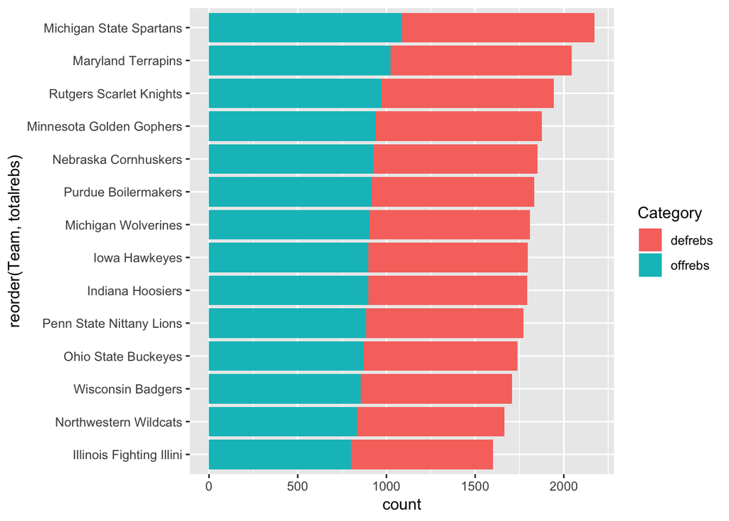

```r
big10stacked <- logs %>% filter(Conference == "Big Ten") %>% group_by(Team) %>% summarize(offrebs = sum(TeamOffRebounds), totalrebs = sum(TeamTotalRebounds)) %>% mutate(defrebs = totalrebs-offrebs) %>% gather(Category, Value, -Team, -totalrebs)

ggplot(big10stacked) + geom_bar(aes(x=reorder(Team, totalrebs), weight=totalrebs, fill=Category)) + coord_flip()
```

But what if I just want to compare two teams? We want a waffle. First we need our values from the two teams we want to compare.

```r
big10stacked %>% filter(Team == "Nebraska Cornhuskers" | Team == "Michigan State Spartans")
```

| Team | totalrebs | Category | Value |
| --- | --- | --- | --- |
| Michigan State Spartans | 1087 | offrebs | 282 |
| Nebraska Cornhuskers | 926 | offrebs | 251 |
| Michigan State Spartans | 1087 | defrebs | 805 |
| Nebraska Cornhuskers | 926 | defrebs | 675 |

Now we can create the vectors needed, and the waffle chart itself.

```r
library(waffle)

nu <- c("Offensive" = 251, "Defensive" = 675, "Padding" = 161)
ms <- c("Offensive" = 282, "Defensive" = 805, "Padding" = 0)

iron(
 waffle(nu/10, rows = 5, title="Nebraska vs Michigan State", colors = c("black", "red", "white")),
 waffle(ms/10, rows = 5, xlab="1 square = 10 rebounds", colors = c("black", "dark green", "white"))
)
```

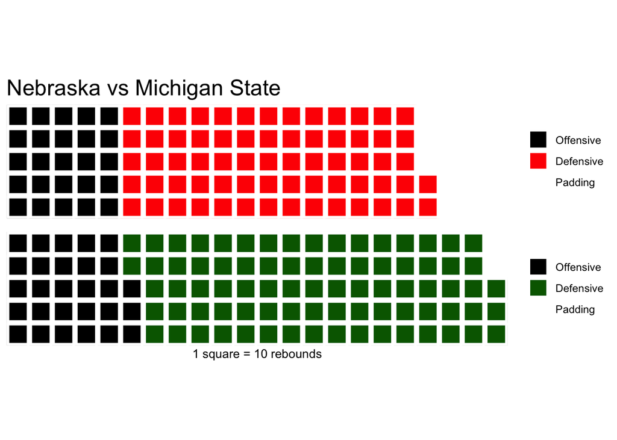

#### My x-axis is a team, but I want to show differences between two numbers

If the gap between two numbers is interesting to you, but you want to look at it by team, an option is the lollipop chart. For that, we need two numbers where a split between them would be meaningful. We can then use `geom_segment` and `geom_point` to make our chart.

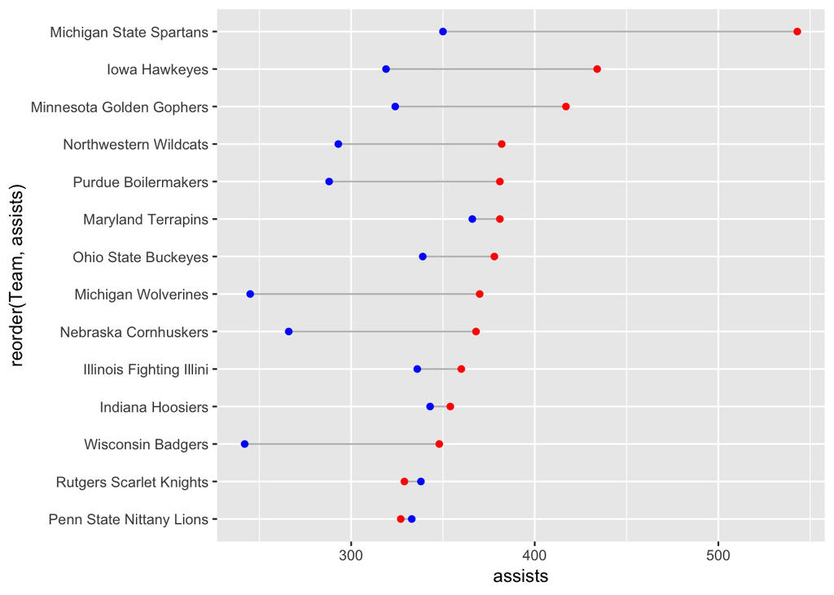

```r
big10loli <- logs %>% filter(Conference == "Big Ten") %>% group_by(Team) %>% summarize(assists = sum(TeamAssists), turnovers = sum(TeamTurnovers))

ggplot(big10loli) +
  geom_segment(aes(x=reorder(Team, assists), xend=Team, y=assists, yend=turnovers), color="grey") +
  geom_point(aes(x=reorder(Team, assists), y=assists), color="red") +
  geom_point(aes(x=reorder(Team, assists), y=turnovers), color="blue") +
  coord_flip()
```